```r
library(tidyverse)
library(ggplot2)
library(broom)
library(readxl)
library(tidytext)
library(dplyr)
library(tm)
library(SnowballC)
library(lubridate)
```

```r
Palestine_news_articles <- read_xlsx("../data/Palestine_news_articles.xlsx")
Israel_news_articles <- read_xlsx("../data/israel_news_articles.xlsx")
Gaza_news_articles <- read_xlsx("../data/gaza_news_articles.xlsx")
chat_gpt_article_headlines <- read_xlsx("../data/chat_gpt_data (1).xlsx")
additional_news_data <- read_csv("../data/news_data.csv")
million_news <- read_csv("../data/abcnews-date-text 2 (1).csv")
tidy_pna <- Palestine_news_articles %>%
  select("...2", "...3", "...4", "...5") %>%
  rename("title" = "...2",
         "journal" = "...3",
         "date" = "...4",
         "description" = "...5") %>%
  filter(!is.na(title)) %>%
  filter(title != "Title",
         journal != "Journal",
         date != "Date",
         description != "Description") %>%
  filter(!str_starts(journal, "#")) %>%
  mutate(keyword = "palestine") %>%
  distinct()
```

```r
tidy_ina <- Israel_news_articles %>%
  select("...2", "...3", "...4", "...5") %>%
  rename("title" = "...2",
         "journal" = "...3",
         "date" = "...4",
         "description" = "...5") %>%
  filter(!is.na(title)) %>%
  filter(title != "Title",
         journal != "Journal",
         date != "Date",
         description != "Description") %>%
  filter(!str_starts(journal, "#")) %>%
  mutate(keyword = "israel") %>%
  distinct()
```

```r
tidy_gna <- Gaza_news_articles %>%
  select("...2", "...3", "...4", "...5") %>%
  rename("title" = "...2",
         "journal" = "...3",
         "date" = "...4",
         "description" = "...5") %>%
  filter(!is.na(title)) %>%
  filter(title != "Title",
         journal != "Journal",
         date != "Date",
         description != "Description") %>%
  filter(!str_starts(journal, "#")) %>%
  mutate(keyword = "gaza") %>%
  distinct()
```

```r
pidf <- full_join(tidy_pna, tidy_ina)
all_data <- full_join(pidf, tidy_gna)
```

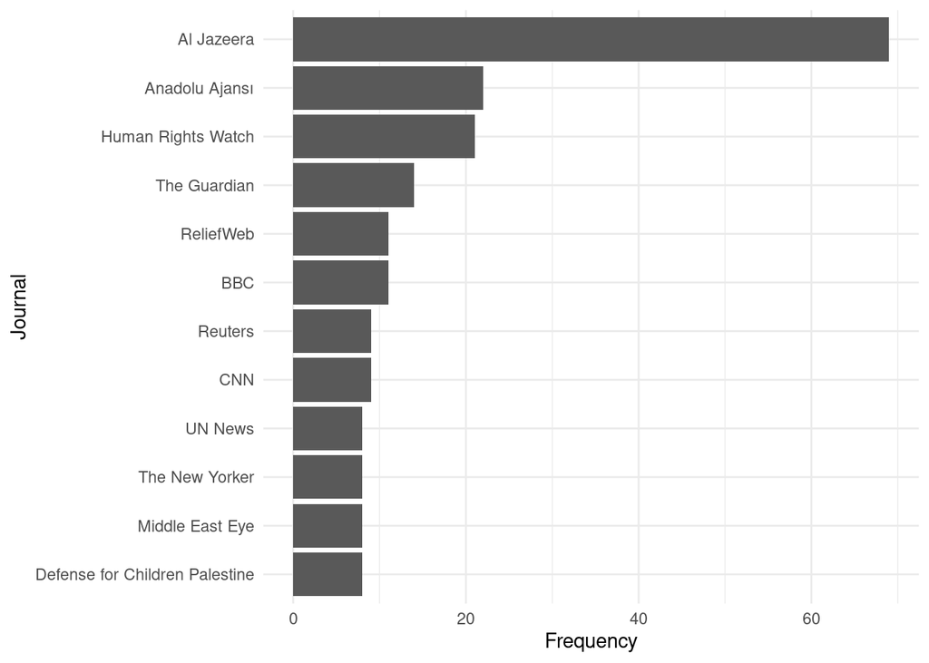

```r
tidy_pna %>%
  count(journal) %>%
  top_n(10, n) %>%
  ggplot(aes(x = reorder(journal, n), y = n)) +
  geom_col() +
  coord_flip() +
  labs(x = "Journal", y = "Frequency") +
  theme_minimal()
```

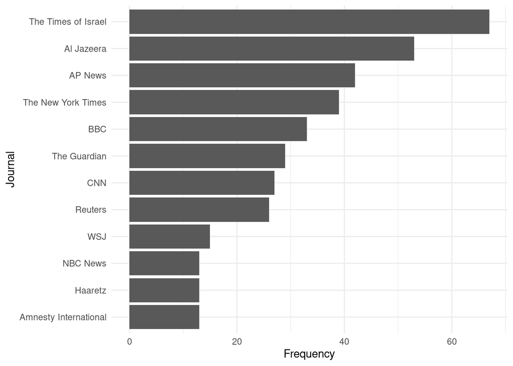

```r
tidy_ina %>%
  count(journal) %>%
  top_n(10, n) %>%
  ggplot(aes(x = reorder(journal, n), y = n)) +
  geom_col() +
  coord_flip() +
  labs(x = "Journal", y = "Frequency") +
  theme_minimal()
```

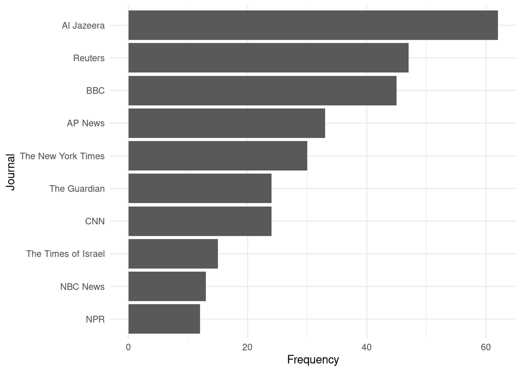

```r
tidy_gna %>%
  count(journal) %>%
  top_n(10, n) %>%
  ggplot(aes(x = reorder(journal, n), y = n)) +
  geom_col() +
  coord_flip() +
  labs(x = "Journal", y = "Frequency") +
  theme_minimal()
```

```r
pidf %>%
  group_by(title, journal, description) %>%
  summarize(count_of_string = n()) #%>%
```

```
## # A tibble: 1,004 × 4
## # Groups:   title, journal [983]
##    title                                     journal description count_of_string
##    <chr>                                     <chr>   <chr>                 <int>
##  1 10 books to help you understand Israel a… UNSW S… "10 books …               1
##  2 100-200,000, Not Two Million': Israel's … Haaretz "100-200,0…               1
##  3 2913 Palestinian children killed in Gaza… Defens… "34 Palest…               1
##  4 3,268 Israelis evacuated to hospitals si… Anadol… "The Yedio…               1
##  5 326 Palestinian children killed as Israe… Defens… "DCIP has …               1
##  6 34 rockets fired from Lebanon at Israel … The Ti… "The barra…               1
##  7 40 Books to Understand Palestine ‹ Liter… Litera… "From Ghas…               1
##  8 A Left-vs.-Left House Battle, Funded by … The Ne… "Wesley Be…               1
##  9 A Palestinian and an Israeli physician s… The La… "As doctor…               1
## 10 A Prayer for the Israel Palestine Confli… The As… "A Prayer …               1
## # ℹ 994 more rows
```

```r
  # mutate(count_of_string = n) %>%
  #mutate(keyword = if_else(count_of_string == 1, keyword, "Both"))
```

```r
inner_join_df <- tidy_pna %>%
  inner_join(tidy_ina, by = c("title", "journal", "description")) %>%
  mutate(keyword = "Both") %>%
  select(title, journal, description, keyword)
tokenized_df <- left_join(pidf, inner_join_df, by = c("title", "journal", "description"))
  colnames(tokenized_df)[5] ="keyword"
  colnames(tokenized_df)[6] ="in_both"

tokenized_df <- tokenized_df %>%
  distinct() %>%
  mutate(in_both = if_else(in_both == "Both", T, F))
```

```r
sentiments <- get_sentiments("bing")
stop_words <- get_stopwords()

tokenized_df <- tokenized_df %>%
  mutate(Title = title) %>%
  unnest_tokens(word, title) %>%
  anti_join(stop_words)
tokenized_df2 <- tokenized_df %>%
  mutate(Description = description) %>%
  unnest_tokens(word, description) %>%
  anti_join(stop_words)
tokenized_df <- tokenized_df %>%
  mutate(title_or_description = "title")

tokenized_df2 <- tokenized_df2 %>%
  mutate(title_or_description = "description")

colnames(tokenized_df)[3] ="Description"

All_tokens <- tokenized_df %>%
  full_join(tokenized_df2, by = c("journal", "keyword", "in_both", "Title", "word", "Description", "title_or_description"))
```

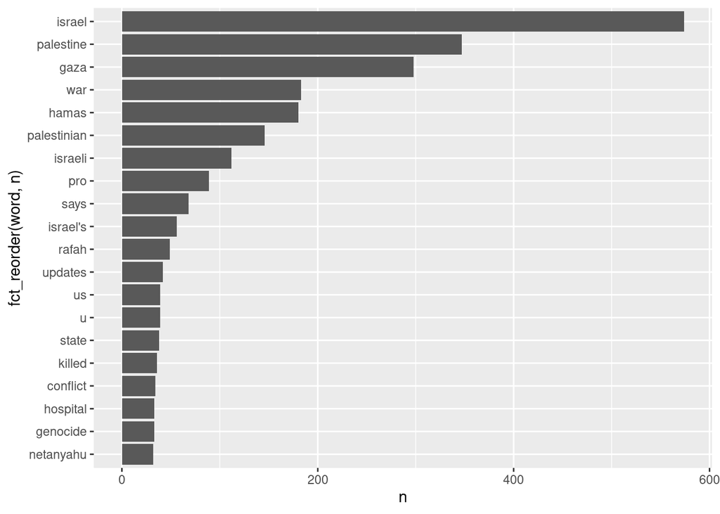

```r
tokenized_df %>%
    count(word, sort = TRUE) %>%
    slice_max(n, n = 20) %>%
    ggplot(aes(n, fct_reorder(word, n))) +
    geom_col()
```

```r
# data$word <- wordStem(data$word)
```

```r
tokenized_df %>%
  inner_join(sentiments) %>%
  group_by(sentiment) %>%
  filter(in_both == F) %>%
  filter(keyword == "palestine") %>%
  count(sentiment, word, sort = T) %>%
  filter(sentiment == "positive")
```

```
## # A tibble: 0 × 3
## # Groups:   sentiment [0]
## # ℹ 3 variables: sentiment <chr>, word <chr>, n <int>
```

```r
tokenized_df %>%
  inner_join(sentiments) %>%
  group_by(sentiment) %>%
  filter(in_both == F) %>%
  filter(keyword == "israel") %>%
  count(sentiment, word, sort = T) %>%
  filter(sentiment == "positive")
```

```
## # A tibble: 0 × 3
## # Groups:   sentiment [0]
## # ℹ 3 variables: sentiment <chr>, word <chr>, n <int>
```

```r
all_data %>%
  unnest_tokens(word, title) %>%
  anti_join(stop_words) %>%
  group_by(journal) %>%
  count(word, sort = TRUE) %>%
  mutate(total_words = sum(n)) %>%
  mutate(word_percentage = n/total_words) %>%
  #arrange(desc(word_percentage)) %>%
  mutate(weighted_percentage = word_percentage * log(total_words)) %>%  # Applying weighting to
  #arrange(desc(weighted_percentage)) %>%
  arrange(desc(word_percentage)) %>%
  #filter(!(word %in% c("palestine", "israel", "gaza")))
  filter(word == "hamas") %>%
  filter(n >= 10)
```

```
## # A tibble: 8 × 6
## # Groups:   journal [8]
##   journal            word      n total_words word_percentage weighted_percentage
##   <chr>              <chr> <int>       <int>           <dbl>               <dbl>
## 1 CNN                hamas    34         522          0.0651               0.408
## 2 AP News            hamas    34         744          0.0457               0.302
## 3 NBC News           hamas    10         264          0.0379               0.211
## 4 The New York Times hamas    19         554          0.0343               0.217
## 5 Al Jazeera         hamas    41        1469          0.0279               0.204
## 6 Reuters            hamas    14         661          0.0212               0.138
## 7 The Times of Isra… hamas    17         872          0.0195               0.132
## 8 BBC                hamas    13         692          0.0188               0.123
```

```r
  #unnest_tokens(word, description)
```

```r
# All_tokens %>%
#   group_by(word) %>%
#   summarize(word_count = n(), journal, date, Description, keyword, in_both, Title, word, title_or_description) %>%
#   mutate(total_words = sum(n)) %>%
#   mutate(word_percentage = n/total_words) %>%
#   mutate(weighted_percentage = word_percentage * log(total_words)) %>%
#   arrange(desc(word_percentage)) %>%
#   group_by(word)
```

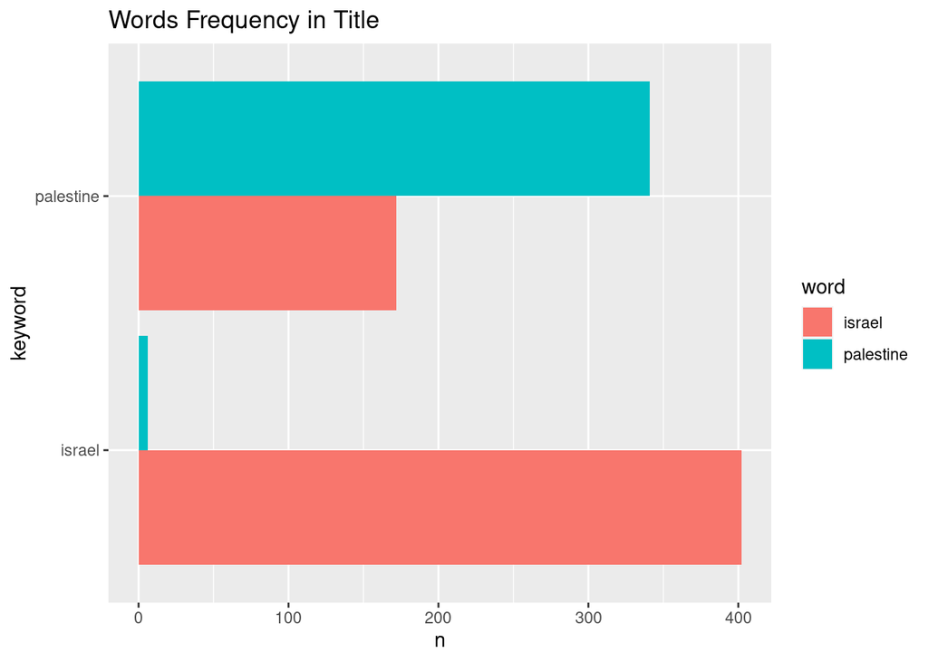

```r
tokenized_df %>%
  group_by(keyword) %>%
  count(word, sort = TRUE) %>%
  filter(word %in% c("palestine", "israel")) %>%
  ggplot(aes(x = keyword, y = n, fill = word)) +
  geom_col(position = "dodge") +
  coord_flip() +
  labs(title = "Words Frequency in Title")
```

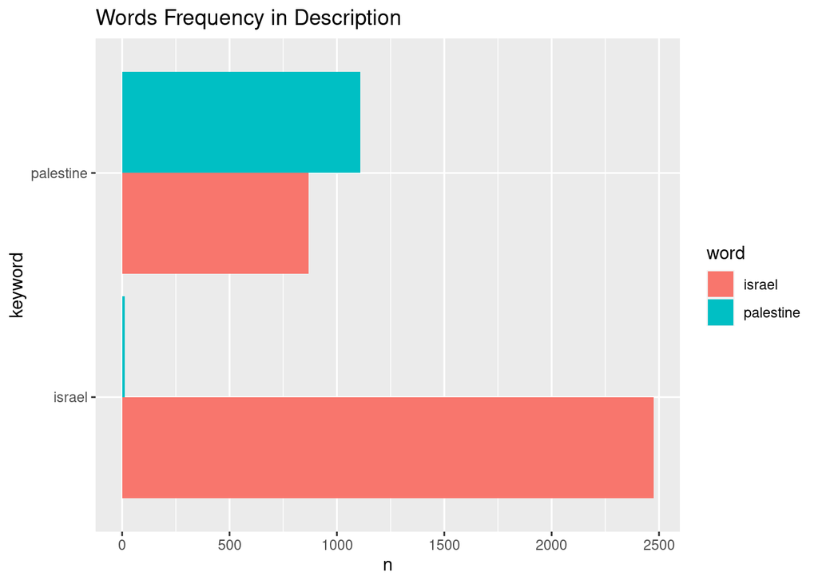

```r
tokenized_df2 %>%
  group_by(keyword) %>%
  count(word, sort = TRUE) %>%
  filter(word %in% c("palestine", "israel")) %>%
  ggplot(aes(x = keyword, y = n, fill = word)) +
  geom_col(position = "dodge") +
  coord_flip() +
  labs(title = "Words Frequency in Description")
```

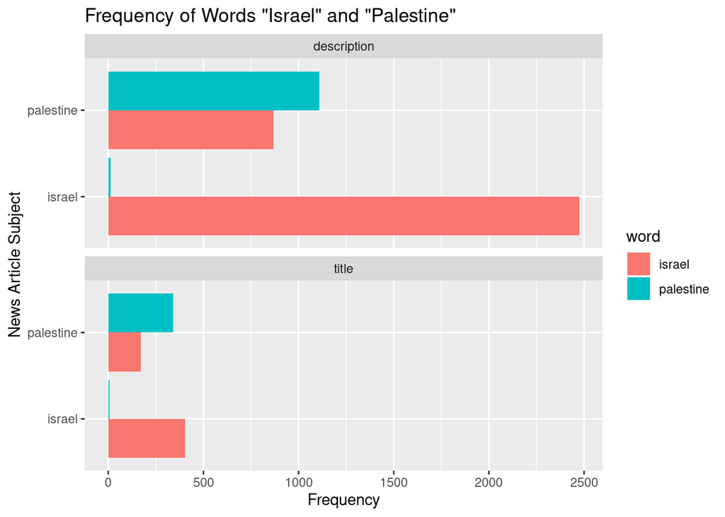

```r
All_tokens %>%
  group_by(keyword, title_or_description) %>%
  count(word, sort = TRUE) %>%
  filter(word %in% c("palestine", "israel")) %>%
  ggplot(aes(x = keyword, y = n, fill = word)) +
  geom_col(position = "dodge") +
  coord_flip() +
  labs(title = 'Frequency of Words "Israel" and "Palestine"') +
  xlab("News Article Subject") +
  ylab("Frequency") +
  facet_wrap(~title_or_description, nrow = 2)
```

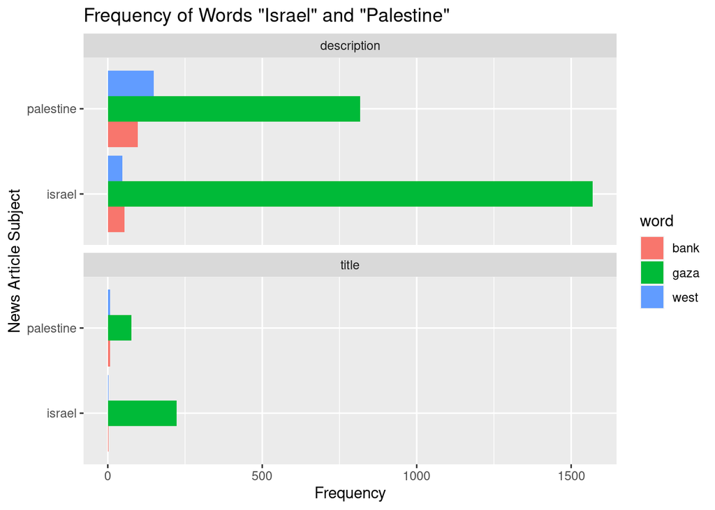

```r
All_tokens %>%
  group_by(keyword, title_or_description) %>%
  count(word, sort = TRUE) %>%
  filter(word %in% c("gaza", "west", "bank")) %>%
  ggplot(aes(x = keyword, y = n, fill = word)) +
  geom_col(position = "dodge") +
  coord_flip() +
  labs(title = 'Frequency of Words "Israel" and "Palestine"') +
  xlab("News Article Subject") +
  ylab("Frequency") +
  facet_wrap(~title_or_description, nrow = 2)
```

```r
gpt <- chat_gpt_article_headlines

pgpt <- chat_gpt_article_headlines %>%
  select(Palestine_headings)

igpt <- chat_gpt_article_headlines %>%
  select(Israel_headings)
```

```r
pgpt %>%
  unnest_tokens(word, Palestine_headings) %>%
  anti_join(stop_words) %>%
  inner_join(sentiments) %>%
  group_by(sentiment) %>%
  count(sentiment, word, sort = T)
```

```
## # A tibble: 246 × 3
## # Groups:   sentiment [2]
##    sentiment word            n
##    <chr>     <chr>       <int>
##  1 negative  conflict      158
##  2 positive  peace          90
##  3 positive  innovation     73
##  4 negative  crisis         67
##  5 positive  sustainable    47
##  6 positive  unity          37
##  7 positive  wins           31
##  8 negative  struggle       28
##  9 positive  renewed        28
## 10 positive  advocate       24
## # ℹ 236 more rows
```

```r
igpt %>%
  unnest_tokens(word, Israel_headings) %>%
  anti_join(stop_words) %>%
  inner_join(sentiments) %>%
  group_by(sentiment) %>%
  count(sentiment, word, sort = T)
```

```
## # A tibble: 167 × 3
## # Groups:   sentiment [2]
##    sentiment word             n
##    <chr>     <chr>        <int>
##  1 negative  condemns       135
##  2 positive  breakthrough    96
##  3 positive  innovation      65
##  4 positive  peace           61
##  5 positive  innovative      52
##  6 positive  diplomatic      42
##  7 positive  sustainable     37
##  8 negative  thwart          34
##  9 positive  support         33
## 10 positive  boost           30
## # ℹ 157 more rows
```

```r
distinct_igpt <- igpt %>%
  distinct()

distinct_pgpt <- pgpt %>%
  distinct()
```

```r
palestine_million <- million_news %>%
  filter(str_detect(headline_text, fixed("palestine", ignore_case = T)) |
           str_detect(headline_text, fixed("palestinian", ignore_case = T)) |
           str_detect(headline_text, fixed("gaza", ignore_case = T)) |
           str_detect(headline_text, fixed("west bank", ignore_case = T))) %>%
  mutate(keyword = "palestine")

israel_million <- million_news %>%
  filter(str_detect(headline_text, fixed("israel", ignore_case = T))) %>%
  mutate(keyword = "israel")
           #str_detect(headline_text, fixed("tel aviv", ignore_case = T)))

million_df <- full_join(palestine_million, israel_million, by = c("publish_date", "headline_text", "keyword"))
```

```r
additional_news_data <- additional_news_data %>%
  rename(title = headline)

million_df <- million_df %>%
  rename(title = headline_text,
         date = publish_date)

million_df$date <- ymd(million_df$date)

million_df$date <- format(million_df$date, "%d-%m-%Y")

joining <- full_join(additional_news_data, million_df, by = c("title", "date"))
```

```r
all_real_data <- pidf %>%
  #select(!date) %>%
  full_join(joining, by = c("title", "description", "keyword")) %>%
  rename(date = date.y, untidy_date = date.x)


tokenized_df3 <- all_real_data %>%
  mutate(Title = title) %>%
  unnest_tokens(word, title) %>%
  anti_join(stop_words)
tokenized_df4 <- all_real_data %>%
  mutate(Description = description) %>%
  unnest_tokens(word, description) %>%
  anti_join(stop_words)
tokenized_df3 <- tokenized_df3 %>%
  mutate(title_or_description = "title")

tokenized_df4 <- tokenized_df4 %>%
  mutate(title_or_description = "description")

colnames(tokenized_df3)[3] ="Description"
colnames(tokenized_df4)[1] ="Title"

all_real_data_tokens <- tokenized_df3 %>%
  full_join(tokenized_df4)
```

[output not shown]

```r
all_real_data_tokens %>%
  filter(!is.na(word)) %>%
  filter(!is.na(keyword)) %>%
  group_by(keyword) %>%
  filter(keyword == "israel")
```

```
## # A tibble: 33,833 × 8
## # Groups:   keyword [1]
##    journal  untidy_date  Description                   keyword date  Title word
##    <chr>    <chr>        <chr>                         <chr>   <chr> <chr> <chr>
##  1 Fox News 22 hours ago FBI Director Christopher Wra… israel  <NA>  FBI … fbi
##  2 Fox News 22 hours ago FBI Director Christopher Wra… israel  <NA>  FBI … dire…
##  3 Fox News 22 hours ago FBI Director Christopher Wra… israel  <NA>  FBI … wray
##  4 Fox News 22 hours ago FBI Director Christopher Wra… israel  <NA>  FBI … makes
##  5 Fox News 22 hours ago FBI Director Christopher Wra… israel  <NA>  FBI … surp…
##  6 Fox News 22 hours ago FBI Director Christopher Wra… israel  <NA>  FBI … isra…
##  7 Fox News 22 hours ago FBI Director Christopher Wra… israel  <NA>  FBI … stop
##  8 Fox News 22 hours ago FBI Director Christopher Wra… israel  <NA>  FBI … amid
##  9 Fox News 22 hours ago FBI Director Christopher Wra… israel  <NA>  FBI … elev…
## 10 Fox News 22 hours ago FBI Director Christopher Wra… israel  <NA>  FBI … thre…
## # ℹ 33,823 more rows
## # ℹ 1 more variable: title_or_description <chr>
```

```r
all_real_data_tokens %>%
  filter(!is.na(word)) %>%
  filter(!is.na(keyword)) %>%
  group_by(keyword) %>%
  filter(keyword == "palestine")
```

```
## # A tibble: 27,798 × 8
## # Groups:   keyword [1]
##    journal      untidy_date  Description               keyword date  Title word
##    <chr>        <chr>        <chr>                     <chr>   <chr> <chr> <chr>
##  1 The Nation   12 hours ago Hundreds of protesters o… palest… <NA>  The … move…
##  2 The Nation   12 hours ago Hundreds of protesters o… palest… <NA>  The … pale…
##  3 The Nation   12 hours ago Hundreds of protesters o… palest… <NA>  The … takes
##  4 The Nation   12 hours ago Hundreds of protesters o… palest… <NA>  The … moma
##  5 The Guardian 1 day ago    Photos displayed at prot… palest… <NA>  Thre… three
##  6 The Guardian 1 day ago    Photos displayed at prot… palest… <NA>  Thre… guil…
##  7 The Guardian 1 day ago    Photos displayed at prot… palest… <NA>  Thre… terr…
##  8 The Guardian 1 day ago    Photos displayed at prot… palest… <NA>  Thre… offe…
##  9 The Guardian 1 day ago    Photos displayed at prot… palest… <NA>  Thre… para…
## 10 The Guardian 1 day ago    Photos displayed at prot… palest… <NA>  Thre… imag…
## # ℹ 27,788 more rows
## # ℹ 1 more variable: title_or_description <chr>
```

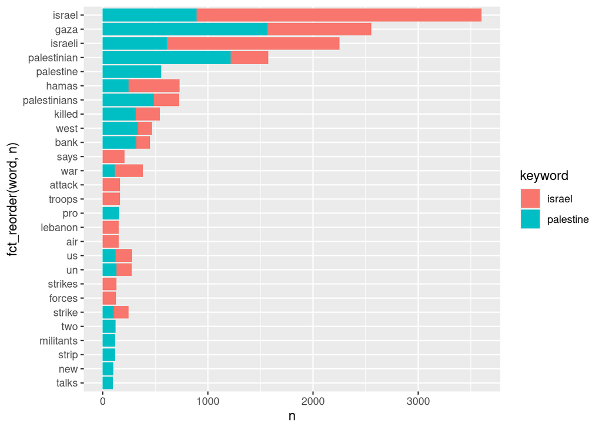

```r
all_real_data_tokens %>%
  filter(!is.na(word)) %>%
  filter(!is.na(keyword)) %>%
  group_by(keyword) %>%
    count(word, sort = TRUE) %>%
    slice_max(n, n = 20) %>%
    ggplot(aes(n, fct_reorder(word, n), fill = keyword)) +
    geom_col()
```

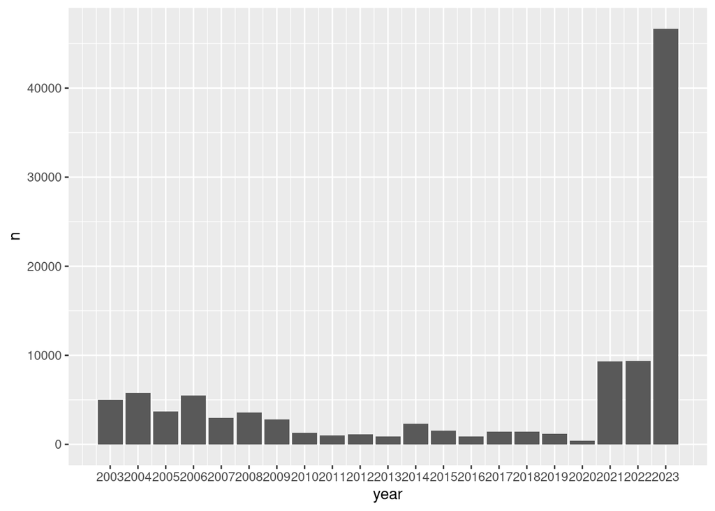

```r
all_real_data <- all_real_data %>%
  mutate(year = str_sub(date, 9, 10)) #%>%
  #mutate(year = as.numeric(year))

all_real_data_tokens <- all_real_data_tokens %>%
  mutate(year = str_sub(date, 7, 10)) %>%
  mutate(year = as.numeric(year))

all_real_data_tokens %>%
  #filter(!is.na(year)) %>%
  count(year) %>%
  ggplot(aes(x = year, y = n)) +
  geom_col() +
  scale_x_continuous(breaks = seq(2003, 2023, by = 1))
```

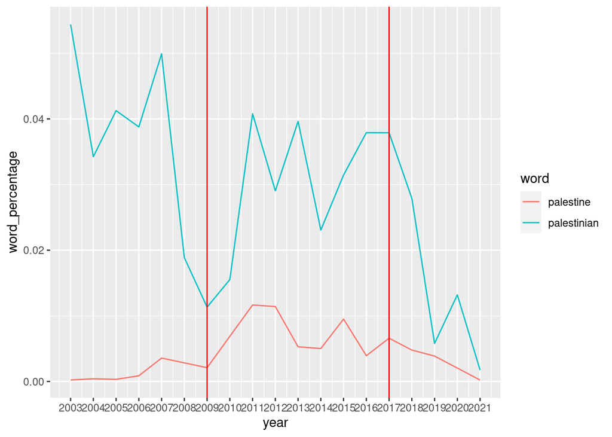

```r
all_real_data_tokens %>%
  group_by(year) %>%
  filter(!is.na(year), !is.na(word)) %>%
  count(word, sort = TRUE) %>%
  mutate(total_words = sum(n)) %>%
  mutate(word_percentage = n/total_words) %>%
  filter(word %in% c("palestine", "palestinian")) %>%
  group_by(word) %>%
  ggplot(aes(x = year, y = word_percentage, colour = word)) +
  geom_line()+
  scale_x_continuous(breaks = seq(2003, 2023, by = 1)) +
  geom_vline(xintercept = 2009, colour = "red") +
  geom_vline(xintercept = 2017, colour = "red") +
  labs(title = )
```

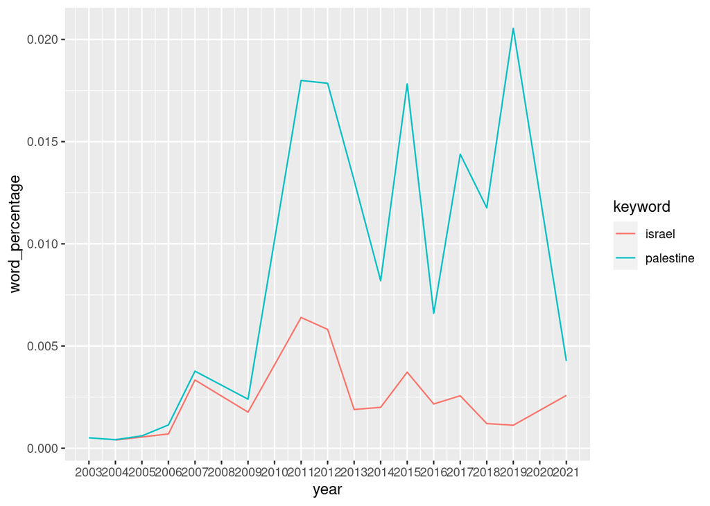

```r
all_real_data_tokens %>%
  group_by(year, keyword) %>%
  filter(!is.na(year), !is.na(word)) %>%
  count(word, sort = TRUE) %>%
  mutate(total_words = sum(n)) %>%
  mutate(word_percentage = n/total_words) %>%
  filter(word %in% c("palestine")) %>%
  group_by(word) %>%
  ggplot(aes(x = year, y = word_percentage, colour = keyword)) +
  geom_line()+
  #geom_smooth()+
  scale_x_continuous(breaks = seq(2003, 2023, by = 1))
```

It appears that between between 2009 to 2011 there is a large increase in the use of the word palestine particularly in news articles about palestine. Why?

2009-2010: Settlement Freeze U.S. President Barack Obama attempted to revive Israeli-Palestinian peace talks shortly after taking office in 2009. At a speech at Cairo University that year, Obama reiterated his support for a two-state solution. Why It Matters: As part of a good faith gesture, Israeli Prime Minister Benjamin Netanyahu implemented a settlement freeze, a key Palestinian demand, that lasted 10 months. While talks briefly restarted, Palestinian Authority President Mahmoud Abbas aborted the talks.

No American president ever came into office with a better understanding of the tragic history of the Palestinians or a deeper commitment to help them achieve independence than Obama. In his Cairo speech in April 2009, Obama solemnly pledged to do everything in his power to bring about Palestinian statehood. - Al Jazeera

Trump was elected in 2017

The 2013–2014 Israeli–Palestinian peace talks were part of the Israeli–Palestinian peace process. Direct negotiations between Israel and the Palestinians began on 29 July 2013 following an attempt by United States Secretary of State John Kerry to restart the peace process.

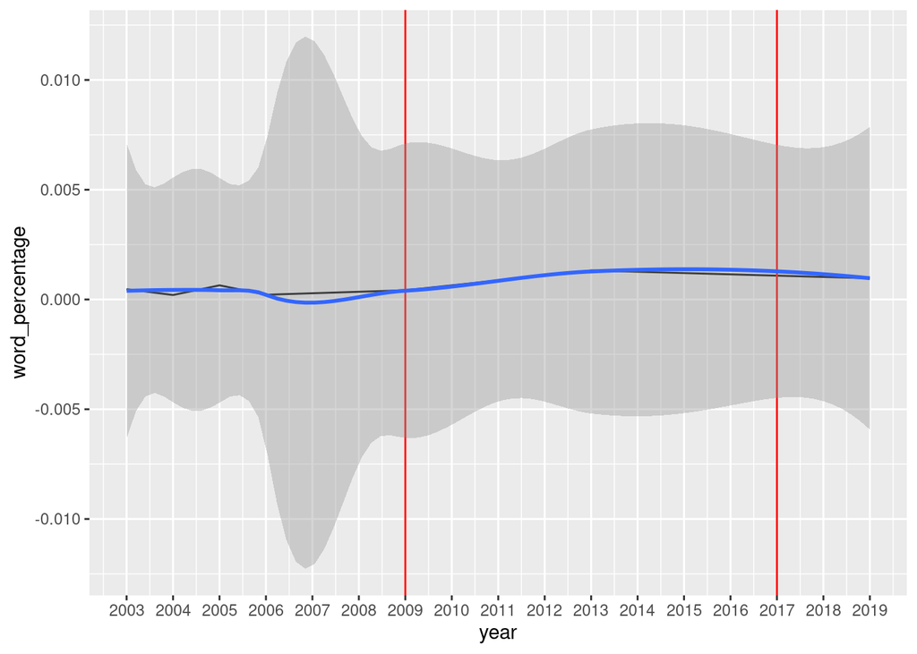

```r
all_real_data_tokens %>%
  group_by(year) %>%
  filter(!is.na(year), !is.na(word)) %>%
  count(word, sort = TRUE) %>%
  mutate(total_words = sum(n)) %>%
  mutate(word_percentage = n/total_words) %>%
  filter(word %in% c("terrorism")) %>%
  group_by(word) %>%
  ggplot(aes(x = year, y = word_percentage)) +
  geom_line()+
  scale_x_continuous(breaks = seq(2003, 2023, by = 1)) +
  geom_vline(xintercept = 2009, colour = "red") +
  geom_vline(xintercept = 2017, colour = "red") +
  geom_smooth()
```

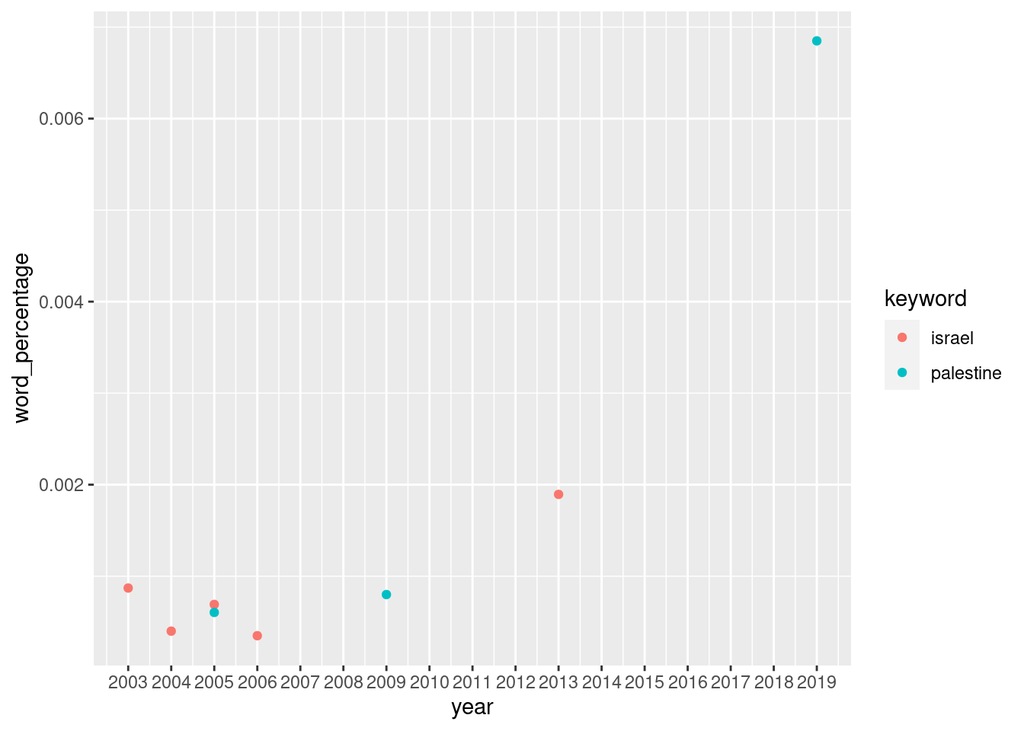

```r
all_real_data_tokens %>%
  group_by(year, keyword) %>%
  filter(!is.na(year), !is.na(word)) %>%
  count(word, sort = TRUE) %>%
  mutate(total_words = sum(n)) %>%
  mutate(word_percentage = n/total_words) %>%
  filter(word %in% c("terrorism")) %>%
  group_by(word) %>%
  ggplot(aes(x = year, y = word_percentage, colour = keyword)) +
  geom_point()+
  #geom_smooth()+
  scale_x_continuous(breaks = seq(2003, 2023, by = 1))
```

```r
All_tokens %>%
  filter(title_or_description == "title")
```

```
## # A tibble: 9,293 × 9
##    journal   date.x Description keyword in_both Title word  title_or_description
##    <chr>     <chr>  <chr>       <chr>   <lgl>   <chr> <chr> <chr>
##  1 The Nati… 12 ho… Hundreds o… palest… NA      The … move… title
##  2 The Nati… 12 ho… Hundreds o… palest… NA      The … pale… title
##  3 The Nati… 12 ho… Hundreds o… palest… NA      The … takes title
##  4 The Nati… 12 ho… Hundreds o… palest… NA      The … moma  title
##  5 The Guar… 1 day… Photos dis… palest… NA      Thre… three title
##  6 The Guar… 1 day… Photos dis… palest… NA      Thre… guil… title
##  7 The Guar… 1 day… Photos dis… palest… NA      Thre… terr… title
##  8 The Guar… 1 day… Photos dis… palest… NA      Thre… offe… title
##  9 The Guar… 1 day… Photos dis… palest… NA      Thre… para… title
## 10 The Guar… 1 day… Photos dis… palest… NA      Thre… imag… title
## # ℹ 9,283 more rows
## # ℹ 1 more variable: date.y <chr>
```

```r
All_tokens %>%
  filter(title_or_description == "description")
```

```
## # A tibble: 127,318 × 9
##    journal   date.x Description keyword in_both Title word  title_or_description
##    <chr>     <chr>  <chr>       <chr>   <lgl>   <chr> <chr> <chr>
##  1 The Nati… <NA>   Hundreds o… palest… NA      The … hund… description
##  2 The Nati… <NA>   Hundreds o… palest… NA      The … prot… description
##  3 The Nati… <NA>   Hundreds o… palest… NA      The … occu… description
##  4 The Nati… <NA>   Hundreds o… palest… NA      The … stor… description
##  5 The Nati… <NA>   Hundreds o… palest… NA      The … muse… description
##  6 The Nati… <NA>   Hundreds o… palest… NA      The … remi… description
##  7 The Nati… <NA>   Hundreds o… palest… NA      The … thea… description
##  8 The Nati… <NA>   Hundreds o… palest… NA      The … world description
##  9 The Nati… <NA>   Hundreds o… palest… NA      The … evade description
## 10 The Nati… <NA>   Hundreds o… palest… NA      The … poli… description
## # ℹ 127,308 more rows
## # ℹ 1 more variable: date.y <chr>
```

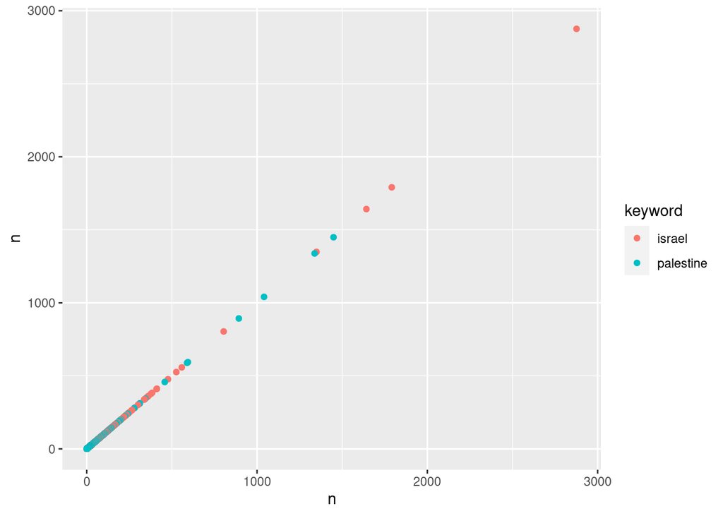

```r
All_tokens%>%
  filter(!is.na(word)) %>%
  filter(!is.na(keyword)) %>%
  group_by(keyword) %>%
  count(word, sort = TRUE) %>%
  ggplot(aes(x = n, y = n, colour = keyword)) +
  geom_point()
```

```r
 all_real_data_tokens <-  all_real_data_tokens %>%
  mutate(fixed_date = case_when(
    str_detect(untidy_date, fixed("2023")) ~ 2023,
    str_detect(untidy_date, fixed("2022")) ~ 2022,
    str_detect(untidy_date, fixed("2021")) ~ 2021,
    str_detect(untidy_date, fixed("2020")) ~ 2020,
    str_detect(untidy_date, fixed("2019")) ~ 2019,
    str_detect(untidy_date, fixed("2018")) ~ 2018,
    str_detect(untidy_date, fixed("2017")) ~ 2017,
    str_detect(untidy_date, fixed("2016")) ~ 2016,
    str_detect(untidy_date, fixed("2015")) ~ 2015,
    str_detect(untidy_date, fixed("2014")) ~ 2014,
    str_detect(untidy_date, fixed("2013")) ~ 2013,
    str_detect(untidy_date, fixed("2012")) ~ 2012,
    str_detect(untidy_date, fixed("2011")) ~ 2011,
    str_detect(untidy_date, fixed("2010")) ~ 2010,
    str_detect(untidy_date, fixed("2009")) ~ 2009,
    str_detect(untidy_date, fixed("2008")) ~ 2008,
    str_detect(untidy_date, fixed("2007")) ~ 2007,
    str_detect(untidy_date, fixed("2006")) ~ 2006,
    str_detect(untidy_date, fixed("2005")) ~ 2005,
    str_detect(untidy_date, fixed("2004")) ~ 2004,
    str_detect(untidy_date, fixed("2003")) ~ 2003,
    str_detect(untidy_date, fixed("2002")) ~ 2002,
    str_detect(untidy_date, fixed("2001")) ~ 2001,
    str_detect(untidy_date, fixed("2000")) ~ 2000,
    is.na(untidy_date) ~ NA,
    .default = 2024
  )) %>%
  mutate(year = if_else(is.na(year), fixed_date, year))
```

```r
additional_news_data <- additional_news_data %>%
  mutate(year = str_sub(date, 9, 10))
```